# PSM - Ukol 1

Josef Bér

# Část 1

## Zadání

- V datech nlschools z knihovny MASS rozhodnete, zda vysledky jazykovych testu zavisi na socioekonomickem statusu. Vysledek jazykoveho testu najdete v promenne lang, socioekonomicky status v promenne SES. U socioekonomickeho statusu porovnavejte pouze 5 skupin vytvorenych podle pocatecni cislice promenne SES. Ohodnotte jak statistickou, tak vecnou vyznamnost, a to nejen celkove pro promennou SES, ale i pro rozdily vsech dvojic socioekonomickych statusu.

## Postup

### 1) načtení knihoven

```r
library(MASS)
library(DescTools)
```

### 2) načtení správných proměnných

```r
jazykovy_test <- nlschools$lang
socioeko_status <- nlschools$SES
# vykreslení prvních deseti hodnot ať vím s čím pracuji
head(jazykovy_test, 10)
head(socioeko_status, 10)
```

### 3) převod socioekonomického statusu na 5 kategorií podle zadání

```r
kategorie <- factor(socioeko_status, levels = levels(kategorie)[1:5])
```

### 4) test normality

```r
res<-residuals(lm(jazykovy_test~kategorie))
PlotQQ(res)
shapiro.test(res)
```

[output not shown]

### 5) test variability (statisticky významná rozdílnost)

```r
boxplot(jazykovy_test~kategorie,main="vysledky testu podle socioeko statusu",col="orange")
```

[output not shown]

```r
oneway.test(jazykovy_test~kategorie, var.equal = FALSE)
```

[output not shown]

### 6) věcná významnost

```r
TukeyHSD(aov(jazykovy_test~factor(kategorie), var.equal = FALSE))
plot(TukeyHSD(aov(jazykovy_test~factor(kategorie))))
```

[output not shown]

10 - 15 a 10 - 18

# Část 2

## Zadání

- Pokuste se cerealni vyrobky hodnocene v datovem sobouru UScereal v knihovne MASS rozdelit do skupin podle meritelnych parametru. Vyzkousejte vice deleni a vyberte to, ktere Vam prijde optimalni.

```r
cereal_data <- UScereal
cereal_data <- subset(cereal_data, select = c("calories", "protein", "fat", "sodium", "fibre", "carbo", "sugars", "potassium"))
```

Z datasetu jsem si vybral pouze sloupce u kterých jsem se rozhodl, že jejich hodnoty mají smysl:

“Calories” - Kalorie “Protein” - Bílkoviny “Fat” - Tuky “Sodium” - Sodík “Fibre” - Vláknina “Carbo” - Sacharidy “Sugars” - Cukry “Potassium” - Draslík

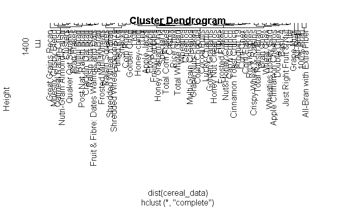

```r
hc <- hclust(dist(cereal_data))
plot(hc, hang = -1)
```

```r
# vidím outliery který jsou specialozovany na nějakou proměnnou a rozhodnul jsem se jich zbavit pro tuto analýzu
```

Protože zde působí mnoho proměnných rozhodl jsem se pro hierarchickou shlukovou analýzu. Z dendrogramu jde vidět, že pár cereálií působí jako outliery oproti ostatním cereáliím - “Grape-Nuts”, “All-Bran”, “100% Bran”, “All-Bran with Extra Fiber”. Už z názvu jde poznat, že jde o velmi specifické značky co se specializují na nějakou hlavní složku, naproti tomu ostatní cereálie mají přibližně vyvážené všechny hodnoty. Pro zesnadnění další práce jsem se rozhodl tyto outliery odstranit.

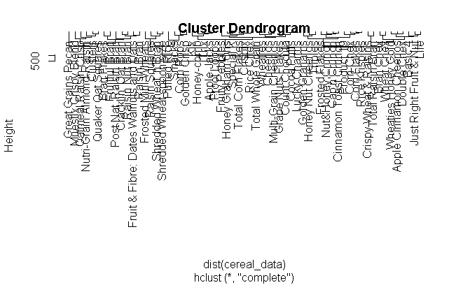

```r
cereal_data <- cereal_data[!(rownames(cereal_data) %in% c("Grape-Nuts", "All-Bran", "100% Bran", "All-Bran with Extra Fiber")), ]
hc <- hclust(dist(cereal_data))
plot(hc, hang = -1)
```

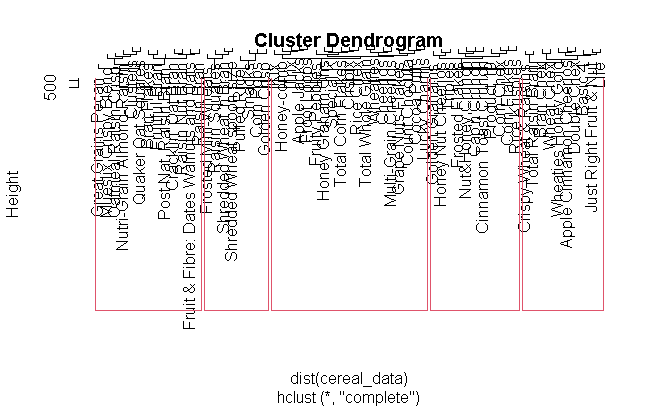

```r
k <- 5
plot(hc)
rect.hclust(hc, k)
```

```r
# Protože jde o dataset kde má vliv hodně proměnných najednou mi nedává smysl použít k-means nebo jiný dvoudimensionální
# přístup.
```

Z nového dendrogramu, který vznikl po odstranění outlierů, jsem se rozhodl, že je zde 5 hlavních shluků.

Protože jde o dataset, kde má vliv mnoho různých proměnných najednou, mi nedává smysl použít k-means nebo jiný dvoudimensionální přístup.

# Část 3

## Zadání

- Vysledky ciselnych testu namerenych v datovem souboru UScereals znazornete vhodnym grafem. K jeho vykresleni vyuzijte faktorovou analyzu, pripadne hlavni komponenty, pokud vhodne faktory nebude mozno vytvorit.

```r
fact_anal <- factanal(~., data = cereal_data, factors = 4,scores = "Bartlett")
fact_anal
```

```
Call:
factanal(x = ~., factors = 4, data = cereal_data, scores = "Bartlett")

Uniquenesses:
 calories   protein       fat    sodium     fibre     carbo    sugars potassium
    0.005     0.248     0.106     0.880     0.069     0.005     0.005     0.028

Loadings:
          Factor1 Factor2 Factor3 Factor4
calories   0.370   0.648   0.517   0.413
protein    0.632   0.481   0.348
fat        0.240   0.889   0.130   0.171
sodium     0.105   0.255   0.173   0.119
fibre      0.923   0.208   0.167
carbo      0.280   0.249   0.914  -0.139
sugars     0.141   0.230           0.957
potassium  0.908   0.215   0.213   0.235

               Factor1 Factor2 Factor3 Factor4
SS loadings      2.381   1.711   1.351   1.212
Proportion Var   0.298   0.214   0.169   0.152
Cumulative Var   0.298   0.511   0.680   0.832

Test of the hypothesis that 4 factors are sufficient.
The chi square statistic is 14.38 on 2 degrees of freedom.
The p-value is 0.000755
```

Z faktorové analýzy mi vyšly 4 faktory:

Faktor 1: Nutriční hodnoty

Tento faktor má vysoké váhy pro vlákninu (fibre), draslík (potassium) a bílkoviny (protein).

Může představovat zdravé složky v cereáliích, které jsou bohaté na vlákninu, bílkoviny a minerály.

Faktor 2: Energetické složky

Tento faktor má vysoké váhy pro kalorie (calories) a tuky (fat).

Může indikovat energetickou hustotu cereálií, kde vyšší hodnoty mohou znamenat větší kalorickou hodnotu a obsah tuků.

Faktor 3: Složení uhlohydrátů

Tento faktor má vysoké váhy pro sacharidy (carbo).

Faktor 4: Obsah cukru

Tento faktor má vysokou váhu pro cukry (sugars).

Ukazuje, že cukry jsou samostatnou složkou, která může být v cereáliích přítomna nezávisle na ostatních nutričních hodnotách.